# Deriving most-likely locations within a PLSS description area using site characteristics

Jay Skovlin and D.E. Beaudette

2022-12-29

## Introduction

Most soil survey data contains site-level information such as slope gradient, slope aspect (degrees or classes), and elevation recorded for each site. PLSS centroids are at best gross approximations of site locations - can we do better? How do we use this information to take a PLSS centroid location and determine where in that section are the most likely locations of a site?

This tutorial demonstrates how to use functions in the [sharpshootR](http://ncss-tech.github.io/AQP/sharpshootR/sharpshootR-Intro.html) package and combine them with other packages to create a decision support tool that can be used to determine a most-likely location by using additional site-level data.

## Background

Before the days of GPS technology the system used for locating sampling sites was the [Public Lands Survey System (PLSS)](https://en.wikipedia.org/wiki/Public_Land_Survey_System) description method. Locating the data was accomplished using several different methods. Sometimes the data was marked on a topographic map or pin-pricked and labeled on aerial photographs and then a PLSS description was derived for these locations. Other times it was not marked on maps at all and was only given a PLSS location on the field sheet. We may be limited in our ability to spatially locate data based only on PLSS descriptions due to the inherent accuracy of the system and depending on what level of detail was recorded in the PLSS description. At the section level we are talking about a square mile area (640 acres) while at the quarter-quarter section we are looking at a much smaller area of 40 acres. Given a PLSS geometry we can identify areas slope gradient, slope aspect, and elevation within that sectional area that are most similar to what was identified by the soil scientist during the original observation. While this process still requires checking, it has the potential to get much closer to the actual locations of sites than could be achieved by deriving only PLSS section or quarter section centroids.

### Steps required to accomplish this task

1. generate PLSS centroids for PLSS descriptions
2. fetch geometry for a PLSS centroid location
3. fetch elevation data for geometry, crop to extent and resample to 30m resolution
4. generate slope(degrees) and aspect(cosine transformed) grids from elevation data
5. stack grids
6. sample grid stack at regular interval
7. run distance calculation on sampled data
8. create a grid of the distance values
9. use 1st quantile to get the minimum distance values - points are typically clustered in one area
10. calculate the centroid for the minumum distance values
11. join the centroid coords back to the original data
12. Generate outputs and save to a folder, graphics of stack data, heat map of distance values with minimum distance points, comparison KML file, GE overlay image

### Installation

With a recent version of R (>= 2.15), it is possible to get all of the packages that this tutorial depends on via:

```r
# run these commands in the R console
install.packages('plotKML', dep=TRUE)
install.packages('raster', dep=TRUE)
install.packages('stringi', dep=TRUE)
install.packages('sp', dep=TRUE)
install.packages('rgeos', dep=TRUE)
install.packages('elevatr', dep=TRUE)
install.packages('cluster', dep=TRUE)
```

You will also need the latest version of `sharpshootR`:

```r
install.packages('remotes', dep=TRUE)
remotes::install_github("ncss-tech/sharpshootR", dependencies=FALSE, upgrade_dependencies=FALSE)
```

## Generating some PLSS centroids data

You can use the `formatPLSS()` and the `PLSS2LL()` functions in the sharpshootR package and the [Georeferencing Legacy Pedon Data](http://ncss-tech.github.io/AQP/sharpshootR/georeferencing-legacy-pedon-data.html) tutorial to derive the centroids down to quarter-quarter section PLSS descriptions. The data that we will load below for this example will also include columns for slope, aspect, and elevation as transcribed from the original site and pedon data observations.

```r
# load required packages
library(sharpshootR)
library(elevatr)
library(terra)
library(raster)
library(sf)
library(cluster)
library(xtable)

# build some data
d <- data.frame(
  id=c('JAKECR', 'KOFI27'),
  qq=c('SW', 'NE'),
  q=c('NW', 'SW'),
  s=c(21, 10),
  t=c('T8N', 'T26N'),
  r=c('R8W', 'R29W'),
  type=c('SN', 'SN'),
  m='MT20',
  slope=c(8, 15),
  aspect=c('W.SW', 32),
  elevation=c(5460, 3540),
  lat=c(46.43493, 48.02308),
  lon=c(-112.6162, -115.3249),
  stringsAsFactors = FALSE
)
```

| id | qq | q | s | t | r | type | m | slope | aspect | elevation | lat | lon |
| --- | --- | --- | --- | --- | --- | --- | --- | --- | --- | --- | --- | --- |
| JAKECR | SW | NW | 21 | T8N | R8W | SN | MT20 | 8 | W.SW | 5460 | 46.43493 | -112.6162 |
| KOFI27 | NE | SW | 10 | T26N | R29W | SN | MT20 | 15 | 32 | 3540 | 48.02308 | -115.3249 |

## Deriving centroids from PLSS information

First we load our data file and run some preparation steps to get it ready. For example, this particular dataset had some aspect values that were classed and some that were in numeric format. We will assign the classed data aspect degree mid-points and then convert the format from character to numeric data type. Circular degree aspect values are difficult to use, so we will convert them to radians and then perform a cosine transformation on the data. Slope values also need to be converted from percent slope to slope degrees. We will also set up a label which indicates the level at which the PLSS coordinates were derived (quarter-quarter, quarter, or section) which can be use in the outputs later on.

```r
# data prep:
# assign any classed aspect strings a class mid-point
d$aspect_deg <- sapply(d$aspect, function(x) {
                                    switch(x,
                                      'N' = '0',
                                      'N.NE' = '22',
                                      'NE' = '45',
                                      'E.NE' = '67',
                                      'E' = '90',
                                      'E.SE' = '112',
                                      'SE' = '135',
                                      'S.SE' = '157',
                                      'S' = '180',
                                      'S.SW' = '202',
                                      'SW' = '225',
                                      'W.SW' = '247',
                                      'W' = '270',
                                      'W.NW' = '292',
                                      'NW' = '315',
                                      'N.NW' = '337',
                                      x
                                    )
                                  })

# convert to numeric format
d$aspect_deg <- as.numeric(d$aspect_deg)

# convert degrees to radians
aspect_rad <- (d$aspect_deg * (180/pi))
#transform radians
d$aspect_cos <- cos(aspect_rad)

# slope: convert from percent to degrees
d$slope_deg <- (atan(d$slope/100) / (pi/180))
d$slope_deg <- round(d$slope_deg, 0)

# set a labeling column to identify the level of PLSS described
d$flag <- ifelse(!is.na(d$qq), 'QQ', ifelse((is.na(d$qq) & !is.na(d$q)), 'Q', ifelse((is.na(d$qq) & is.na(d$q)), 'S', '')))

# show data
knitr::kable(d)
```

| id | qq | q | s | t | r | type | m | slope | aspect | elevation | lat | lon | aspect_deg | aspect_cos | slope_deg | flag |
| --- | --- | --- | --- | --- | --- | --- | --- | --- | --- | --- | --- | --- | --- | --- | --- | --- |
| JAKECR | SW | NW | 21 | T8N | R8W | SN | MT20 | 8 | W.SW | 5460 | 46.43493 | -112.6162 | 247 | -0.6841456 | 5 | QQ |
| KOFI27 | NE | SW | 10 | T26N | R29W | SN | MT20 | 15 | 32 | 3540 | 48.02308 | -115.3249 | 32 | 0.3387905 | 9 | QQ |

## Fetch PLSS geometry using PLSS centroid coordinates

The `LL2PLSS()` function in the sharpshootR package relies on the GetLatLon functionality of the BLM PLSS web services returns the geometry for a given set of XY coordinates. [BLM PLSS web services](https://gis.blm.gov/arcgis/rest/services/Cadastral/BLM_Natl_PLSS_CadNSDI/MapServer/exts/CadastralSpecialServices/GetLatLon)

```r
# make a copy
# convert to sf object
# point geometry
d1 <- st_as_sf(d, coords = c('lon', 'lat'), crs = 4326)

# set idx to point of interest
idx.pt <- 2
d1[idx.pt, ]
```

|  | id | qq | q | s | t | r | type | m | slope | aspect | elevation | aspect_deg | aspect_cos | slope_deg | flag | geometry |
| --- | --- | --- | --- | --- | --- | --- | --- | --- | --- | --- | --- | --- | --- | --- | --- | --- |
| 2 | KOFI27 | NE | SW | 10 | T26N | R29W | SN | MT20 | 15 | 32 | 3540 | 32 | 0.3387905 | 9 | QQ | POINT (-115.3249 48.02308) |

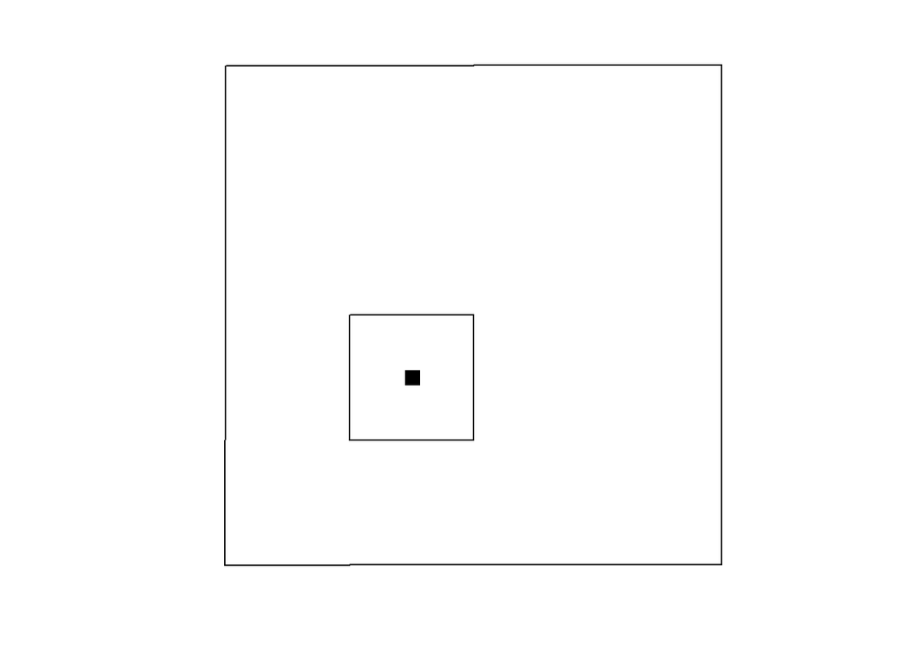

```r
# get geometry for sectional area - note returnlevel = 'S'
p.plss.sec <- LL2PLSS(d$lon[idx.pt], d$lat[idx.pt], returnlevel = 'S')

# get geometry for the quarter-quarter area corresponding to the point intersection
# note default returnlevel='I' used because parameter is left unspecified
p.plss <- LL2PLSS(d$lon[idx.pt], d$lat[idx.pt])

# convert sf objects -> SpatVect (terra) for simplicity
p.plss <- vect(p.plss)
p.plss.sec <- vect(p.plss.sec)
d1 <- vect(d1)

# plot section, quarter-quarter section, and point geometries together
plot(p.plss.sec, axes = FALSE)
lines(p.plss)
points(d1, pch = 15, cex = 1.5)
```

### Fetch elevation data and crop to extent

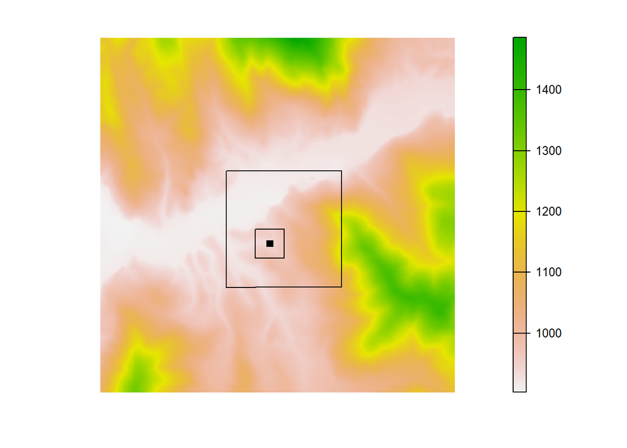

```r
# get elevation data for section geometry
x <- get_elev_raster(st_as_sf(p.plss.sec), z = 14, src = "aws")

# convert to terra object
x <- rast(x)

# visual check
plot(x, axes = FALSE)
lines(p.plss.sec)
lines(p.plss)
points(d1, pch = 15, cex = 1)
```

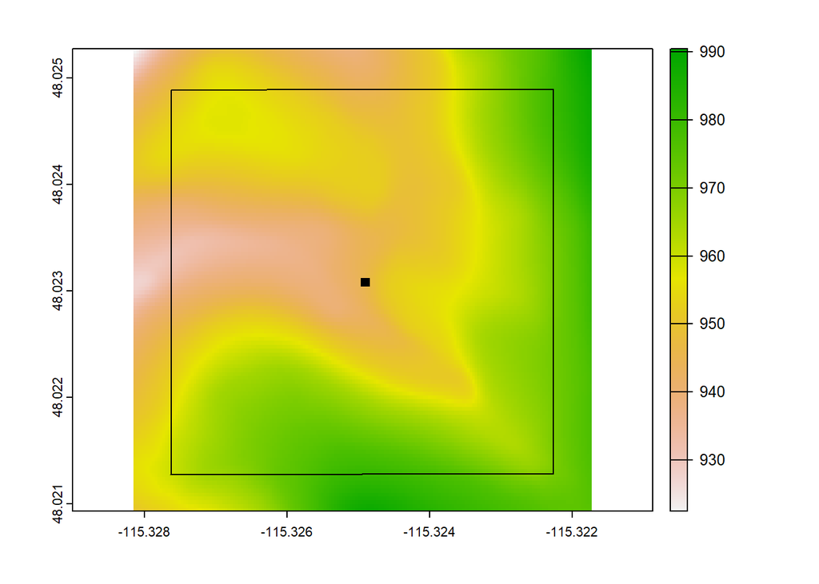

```r
# extract extent
e.qq <- ext(p.plss)
# expand extent slightly
dd <- e.qq * 1.20

# crop section to QQ-section geometry extent
x <- crop(x, dd)

# graphical check
plot(x)
lines(p.plss.sec)
lines(p.plss)
points(d1, pch = 15, cex = 1)
```

### Resample and generate slope and aspect grids and create raster stack

```r
# # resample to 30m res
# x3 <- aggregate(x, fact=9)

# create raster stack of slope and aspect
rs <- terrain(x, v = c('slope'), unit = 'degrees')
rs1 <- terrain(x, v = c('aspect'), unit = 'radians')

# add elevation to raster stack and convert to feet
rs$elevation <- x * 3.28

# transform to cos(aspect_rad)
rs$aspect <- cos(rs1$aspect)
```

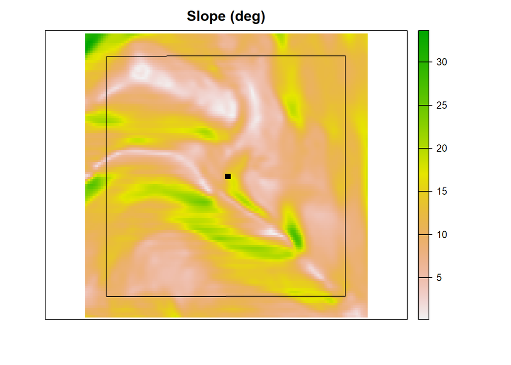

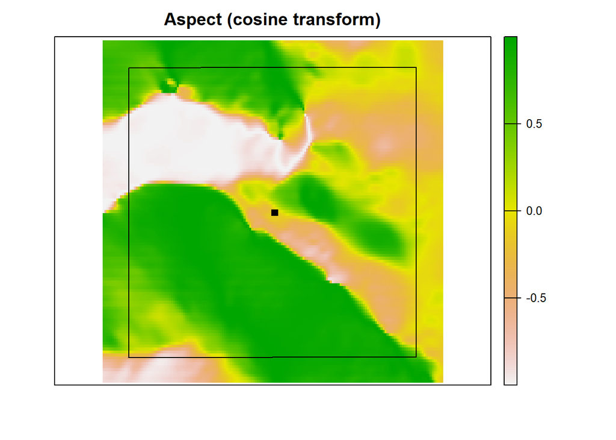

### Sample raster at regular points and run distance calculation

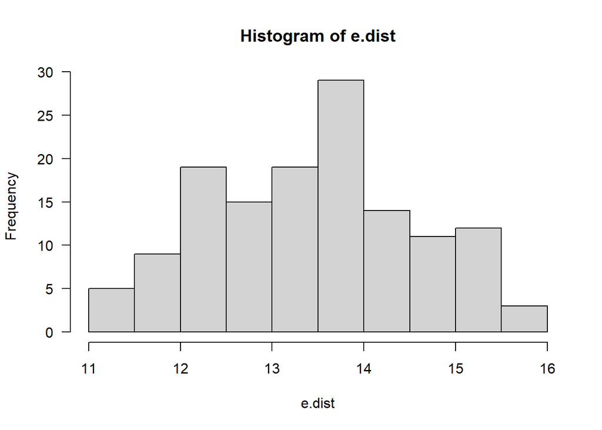

```r
# sample points
a <- spatSample(rs, floor(ncell(rs) / 100), method = 'regular', as.points = TRUE, values = FALSE)

# crop section to QQ-section geometry extent
a <- crop(a, e.qq)

# extract values
e <- extract(rs, a, ID = FALSE)

# append original data, requires adjusting names
o <- d[idx.pt, c('slope_deg', 'elevation', 'aspect_cos')]
names(o) <- names(e)
e <- rbind(e, o)


# run dissimilarity calc
e.dist <- as.matrix(daisy(e, metric = 'euclidean', stand = TRUE))

# extract distances from original point to all other samples
e.dist <- e.dist[nrow(e), -nrow(e)]

hist(e.dist, las = 1)
```

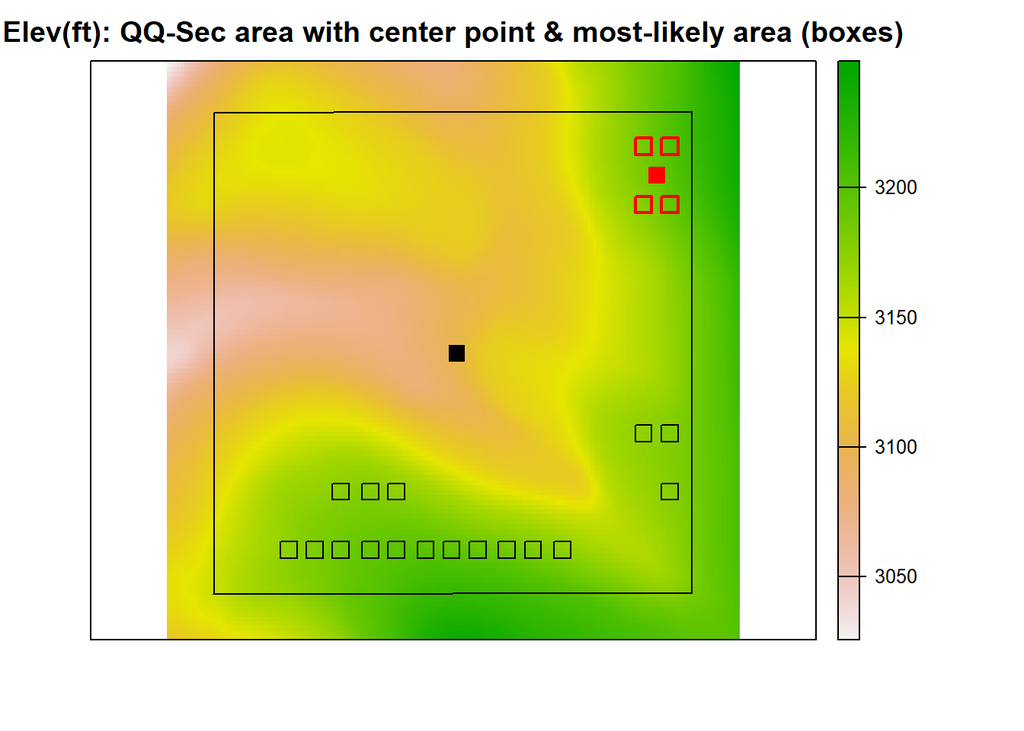

```r
# rank distances
a$distance <- e.dist

# visualize distance map, using aggregated grid topology
#plot(rasterize(a, aggregate(rs$elevation, fact = 9), field = 'distance', fun = mean))

# get index to minimum distance value
idx <- which.min(a$distance)

# create a grid  based on our elevation grid
# convert points in 'a' to pixels
r.dist <- rasterize(a, rs$elevation, field = 'distance', fun = mean)

# removes edge effects from raster
r.dist[cellFromRow(r.dist, 1)] <- NA
r.dist[cellFromRow(r.dist, nrow(r.dist))] <- NA
r.dist[cellFromCol(r.dist, 1)] <- NA
r.dist[cellFromCol(r.dist, ncol(r.dist))] <- NA

# remove edge effects - NA's introduced from sampled data
idx <- complete.cases(as.data.frame(a))
a5 <- a[idx, ]

# copy out dataframe of coordinates as reference for later use
a6 <- as.data.frame(geom(a5))

# use 10th percentile of the distance values to evaluate a subset of minimum distances
# can add an additional weighting factor to further narrow the 1st quantile range of values
idx <- which(a5$distance < quantile(a5$distance, prob = 0.15, na.rm = TRUE))

# find top 4 of the minimum distance score pixels for comparison
idx.ml <- idx[1:4]

plot(rs$elevation, axes = FALSE)
lines(p.plss)
points(a5[idx, ], pch=0, cex=1.5)
points(a5[idx.ml,], pch=0, cex=1.5, lwd=2, col='red')
points(d1[idx.pt, ], pch=15, cex=1.5)
points(mean(a6$x[idx.ml]), mean(a6$y[idx.ml]), pch=15, cex=1.5, lwd=2, col='red')

box()
title(main="Elev(ft): QQ-Sec area with center point & most-likely area (boxes)")
title(sub= "mean of most-likely area coordinates shown as red square")
```

```r
# move coords for most-likely centroid XY back into the original dataframe 'd'
# convert coordinates to dataframe, assign id column, sort and rename columns
# then join back to the original data
lat1 <- mean(a6$y[idx.ml])
lon1 <- mean(a6$x[idx.ml])
coords.ml <- data.frame(lon1, lat1)
coords.ml$id <- d1$id[idx.pt]
coords.ml$mean_dist <- mean(a5$distance[idx])
coords.ml <- coords.ml[, c(3,2,1,4)]
names(coords.ml) <- c('id', 'lat1', 'lon1', 'dist')
d6 <- plyr::join(d, coords.ml, by='id', type='left')
```

## Visual comparison of centroid versus most-likely minimum distance locations

Generate a KML file via the plotKML package and view the resulting centroid location and the nearby mostly-likely locations for the data in Google Earth. Below we first generate a KML file for the centroid and then generate a second KML file for the most-likely locations and map those by applying a color palette to the distance values. This produces a kind of heatmap for the area that is most similar to the centroid based on site characteristics of slope, aspect, and elevation.

```r
# load library
library(plotKML)

# generate comparison kml files
# subset to only ones with lat/long coords
idx <- which(!is.na(d6$lat))
d7 <- d6[idx, ]
# select first row as original centroid
d7 <- d7[1, ]

# initialize SPDF for centroid point
coordinates(d7) <- ~ lon + lat
proj4string(d7) <- '+proj=longlat +datum=NAD83'

kml_file_path <- 'C:/PLSS_locations/R_MT634_KNF_PLSS_centroid.kml'
kml_open(file.name=kml_file_path, folder.name='Site_centroids', overwrite=TRUE)
kml_layer.SpatialPoints(d7, title='Sites_PLSS', colour='orange', labels=paste(d7$id, d7$flag, 'C', sep=' - '), shape="http://maps.google.com/mapfiles/kml/pal2/icon18.png")
kml_close(kml_file_path)

# subset to only ones with lat/long coords
idx <- which(!is.na(d6$lat1))
d8 <- d6[idx, ]

# initialize SPDF for minimum distance points
coordinates(d8) <- ~ lon1 + lat1
proj4string(d8) <- '+proj=longlat +datum=NAD83'

# add color palette
data(SAGA_pal)

kml_file_path <- 'C:/PLSS_locations/R_MT634_KNF_PLSS_minDist.kml'
kml_open(file.name=kml_file_path, folder.name='Site_minDist', overwrite=TRUE)
kml_layer.SpatialPoints(d8, title='Sites_MT634', colour=d8$dist, colour_scale=SAGA_pal[[1]], labels=paste(round(d8$dist, 2), 'mD', sep=' - '), shape="http://maps.google.com/mapfiles/kml/shapes/square.png")
kml_close(kml_file_path)
```

## Conclusion

Most soil survey data has additional site-level information such as slope percent, aspect (degrees or classes), and elevation for each site. This has been a demonstration of how to use this information to take a centroid location and use these outputs as a decision-support system to shift a centroid to the most-likely location based on a distance calculation of the similarity of the recorded site information with the corresponding 30m raster values.

This document is based on `sharpshootR` version 2.0.